# Multiple Comparison Tests in R Programming Language.

1. Introduction to Post Hoc Multiple Comparisons.
2. Fisher’s Least Significant Difference.
3. Experimentwise Error Rates and the Bonferroni Correction.
4. Tukey’s Honestly Significant Difference.

# Introduction to Post Hoc Multiple Comparisons.

**The Basics:**

# Fisher’s Least Significant Difference (LSD).

**The Basics:**

- The method returns a matrix of p-values from a pooled t test $$ t=\frac{\bar y_A-\bar y_B}{s_p\sqrt{\frac1{n_A}+\frac1{n_B}}}$$
- The difference in this the Fisher Least Significant Difference is that the $S_p$ is calculated rom all the $k$ groups from the ANOVA.
- The $S_p$ is the estimate for the $\sigma$ which is the $\hat{\sigma} = \sqrt{MSE}$ from the ANOVA
- The degrees of freedom is the $df_e = N - ks$
- We then obtain the p-value from the t-statistic is then using the `pt()` method in R.
- If we have a two-tailed test then the pvalue assocaited with the test statistic is `2 * pt(t_statistic, df, lower.tail=False)`
- Although the Fisher’s Least Significant Difference (LSD) is easy to implement, it is not encouraged to use since it does not adjust for the likelihood of making a Type I error.
- A Type 1 Error is making a false positive, meaning you reject the Null Hypothesis in favor of the Alternative Hypothesis even though it the alternative is not true.
- The problem with the Fisher LSD is that the experimentwise Type I error rate is larger than our level of significance which is usually alpha at 0.05.
- Example of experimentweise Type I error. If our alpha is 0.05, and if we perform 7 pairwise tests, then the chance of not making a type 1 error $$(1 - \alpha)^7=(1-0.05)^7=(0.95)^7=0.6983$$
- Now after 7 tests then the likelyhood of making at least one Type I error is $1 - 0.6983 = 0.3016$ which is a lot higher than 0.05 level of significance.
- The Fisher LSD does not do anything to control for this experimentwise Type I error rate, which is why it is discouraged to use this test.
- R programming code: `pairwise.t.test`

## Load Data

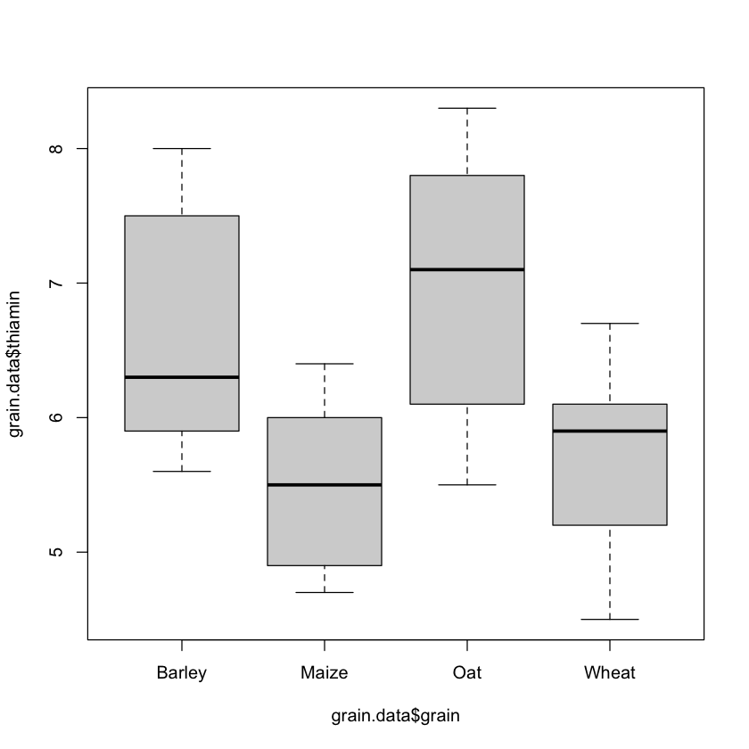

```r
grain.data <- read.csv('static/data/thiamin.csv')
attach(grain.data)
boxplot(grain.data$thiamin~grain.data$grain)
```

## Perform pairwise test

```r
pairwise.t.test(thiamin, grain, p.adjust.method='none')
```

```
	Pairwise comparisons using t tests with pooled SD

data:  thiamin and grain

      Barley Maize  Oat
Maize 0.0405 -      -
Oat   0.4543 0.0079 -
Wheat 0.0939 0.6708 0.0203

P value adjustment method: none
```

# Experimentwise Error Rates and the Bonferroni Correction.

**The Basics:**

- The Bonferroni correction is a post hoc test used after an ANOVA to identify groups that may be different.
- Unlike the Fisher LSD, Bonferroni does control for the experimentwise Type I error rate.
- Bonferroni controls for the experimentwise Type I error rate by using ensuring that the probability of the union of several events is not larger than the sum of those events.s
- Using the example from the Fisher LSD. If we had 7 tests to be performed, then the alpha for each test would be $\alpha=0.05/n_t$, where $n_t=7$ experiments, thus $\alpha=0.05/7 = 0.00714$ is the level of significance for each test
- This makes it more difficult to conclude if there is a difference between groups but it also ensures the type 1 error rate amont all the test is not greater than 0.05.
- The Bonferroni is more conservative BUT less likely to detect an actual differnce if it does exist (Type II error).s
- R Programming Code: `pairwise.t.test(dependent, independent, p.adjust.method='bonferroni')`

## Perform Bonferroni Correction

```r
pairwise.t.test(thiamin, grain, p.adjust.method='bonferroni')
```

```
	Pairwise comparisons using t tests with pooled SD

data:  thiamin and grain

      Barley Maize Oat
Maize 0.243  -     -
Oat   1.000  0.047 -
Wheat 0.564  1.000 0.122

P value adjustment method: bonferroni
```

# Tukey’s Honestly Significant Difference.

**The Basics:**

- Tukey’s Honestly Significant Difference does not rely on two-sample pooled t-test like Fisher LSD and Bonferroni correction tests rely on.
- Tukey's method relies on the Tukey’s studentized distribution, which is a sampling distribution of the standardized difference between the maximum and minimum of the two sample means (out of the overall samples containing the k group sample means.
- This method results in a series of either p-values (for a two-tailed hypothesis test) or confidence intervals where the experimentwise Type I error rate is $\alpha=0.05$ (or any other $\alpha$).
- R Programming Code: `TukeyHSD(aov object)`
- The function returns a matrix of p-values for all possible pairwise combinations.
- The function also includes the 95% confidence interval using the Tukey's studentized range distribution and not the t-distribution.

```r
grain.aov <- aov(grain.data$thiamin~grain.data$grain)
TukeyHSD(grain.aov)
```

```
  Tukey multiple comparisons of means
    95% family-wise confidence level

Fit: aov(formula = grain.data$thiamin ~ grain.data$grain)

$`grain.data$grain`
                   diff         lwr       upr     p adj
Maize-Barley -1.1000000 -2.50582897 0.3058290 0.1601767
Oat-Barley    0.3833333 -1.02249564 1.7891623 0.8699440
Wheat-Barley -0.8833333 -2.28916231 0.5224956 0.3214493
Oat-Maize     1.4833333  0.07750436 2.8891623 0.0363317
Wheat-Maize   0.2166667 -1.18916231 1.6224956 0.9723804
Wheat-Oat    -1.2666667 -2.67249564 0.1391623 0.0867655
```